# Tarea 4: ejercicio práctico

## Antecedentes

Una compañía decidió dar una promoción de 10% en compras a algunos de sus clientes. Nuestro trabajo es entender cuál fue el impacto en ventas de nuestra promoción.

- Nuestro criterio actual de ventas son las ventas de segundo semestre (v_2, antes de quitar el 10% de promoción)
- La promoción se aplicó y comunicó a los clientes a finales del primer semestre.
- Sabemos que el grupo de ventas decidió distribuir más promociones para los clientes de gasto alto en el primer semestre (v_1), aunque no sabemos exactamente cómo hicieron la distribución.

## Equipo 1 de analistas

El equipo 1 de analistas toma los siguientes datos de promoción y gasto de los clientes en el segundo semestre (cuando estuvo activa la promoción):

```r
datos_1 |> select(promo, ventas_2) |> head() |> kbl() |> kable_paper("hover", full_width = F)
```

| promo | ventas_2 |
| --- | --- |
| 0 | 521.3648 |
| 0 | 2195.2229 |
| 1 | 1670.5911 |
| 1 | 1984.3057 |
| 1 | 1641.6840 |
| 1 | 1640.9840 |

```r
res_1 <- lm(ventas_2 ~ promo, data = datos_1) |> tidy()
estimaciones_95 <-
  tibble(inf = res_1$estimate[2] - 2 * res_1$std.error[2],
         sup = res_1$estimate[2] + 2 * res_1$std.error[2],
         equipo = "equipo_1")
res_1
```

```
# A tibble: 2 × 5
  term        estimate std.error statistic   p.value
  <chr>          <dbl>     <dbl>     <dbl>     <dbl>
1 (Intercept)    1283.      8.28     155.  0
2 promo           354.     11.6       30.4 9.55e-193
```

Su estimación es que las ventas aumentaron en promedio 354 +/- 22 debido a la promoción.

Incluso, el equipo 1 también hace una prueba-t para probar la igualdad de medias entre el grupo de promoción y el grupo sin promoción.

```r
t.test(ventas_2  ~  factor(promo), data = datos_analista_1)
```

```
    Welch Two Sample t-test

data:  ventas_2 by factor(promo)
t = -30.455, df = 7996.5, p-value < 2.2e-16
alternative hypothesis: true difference in means between group 0 and group 1 is not equal to 0
95 percent confidence interval:
 -376.7803 -331.2095
sample estimates:
mean in group 0 mean in group 1
       1282.686        1636.681
```

**Pregunta 1** Explica por qué este primer equipo está equivocado en su método. Dibuja un DAG con la descripción de arriba y considera si el coeficiente de su modelo puede interpretarse de manera causal (como efecto de la promoción). Explica en palabras por qué su estimación está inflada con respecto al verdadero efecto de la promoción.

[interactive chart not shown]

**Respuesta:** Este equipo no está considerando que el efecto que estimaron incluye el efecto en promociones por ventas en el primer semestre. Necesitamos controlar por ventas del primer semestre.

> Recordar que (Notas 2 Modelos probabilisticos, al final): En general, para estimar efecto TOTAL de X sobre Y queremos que
> - todos los **caminos causales** entre $X$ y $Y$ estén activos
> - Queremos condicionar para que todos los caminos no causales estén bloqueados (como es el caso del camino $V_1\to Promo \to V2$)

## Equipo 2 de analistas

Un segundo equipo de analistas nota que la distribución de la promoción se hizo según las ventas del semestre anterior, y decide entonces hacer el siguiente modelo, incluyendo las ventas del primer semestre:

```r
res_2 <- lm(ventas_2 ~ factor(promo) + ventas_1,
            data = datos_1) |> tidy()
estimaciones_95 <- estimaciones_95 |> bind_rows(
  tibble(inf = res_2$estimate[2] - 2 * res_2$std.error[2],
         sup = res_2$estimate[2] + 2 * res_2$std.error[2],
         equipo = "equipo_2"))
res_2 |> kbl() |> kable_paper("hover", full_width = F)
```

| term | estimate | std.error | statistic | p.value |
| --- | --- | --- | --- | --- |
| (Intercept) | 494.2722334 | 12.2268894 | 40.42502 | 0 |
| factor(promo)1 | 96.4774257 | 9.5237257 | 10.13022 | 0 |
| ventas_1 | 0.9081879 | 0.0120472 | 75.38572 | 0 |

Su estimación es que la promoción aumentó en promedio las ventas en alrededor de 96 pesos (+- 20)

**Pregunta 2**: Explica por qué las dos estimaciones son distintas, y por qué la respuesta del segundo equipo es mejor que la del primer equipo (usando el DAG).

**Respuesta:** Las estimaciones difieren porque el equipo 2, incluye en su modelo, el hecho de que las ventas durante el primer semestre tienen influencia sobre la promocion, de modo que pueden controlar por esa variable para obtener el efecto total de promoción sobre ventas, sin que se vea influenciado por las ventas en el primer semestre.

Además, el equipo 1 no toma en cuenta que hay un camino no causal entre ventas de primer semestre y ventas 2.

**Pregunta 3**: Supón que por razones administrativas, sólo puedes trabajar con los datos que usó el equipo de analistas 1. ¿Cómo explicarías que no es posible identificar el efecto causal de la promoción solamente usando estos datos?

## Equipo 3 de analistas

Después de estos análisis, alguien nota que hay una variable adicional “status_oro” en la base de datos. Un nuevo equipo 3 decide usar esa variable, pues nota que su modelo tiene mejor resultados predictivos de las ventas del semestre 2:

```r
res_3 <- lm(ventas_2 ~ factor(promo) + ventas_1 + factor(status_oro), data = datos_1) |> tidy()
estimaciones_95 <- estimaciones_95 |> bind_rows(
  tibble(inf = res_3$estimate[2] - 2 * res_3$std.error[2],
         sup = res_3$estimate[2] + 2 * res_3$std.error[2],
         equipo = "equipo_3"))
res_3
```

```
# A tibble: 4 × 5
  term                estimate std.error statistic  p.value
  <chr>                  <dbl>     <dbl>     <dbl>    <dbl>
1 (Intercept)         -153.      17.6        -8.72 3.24e-18
2 factor(promo)1       -19.3      8.79       -2.19 2.85e- 2
3 ventas_1               0.929    0.0107     87.0  0
4 factor(status_oro)1  739.      15.8        46.8  0
```

Su conclusión es que la promoción no funcionó (o quizá dañó las ventas). Argumentan que su modelo es más predictivo que la de los equipos 1 y 2, y que la promoción realmente no funcionó.

**Pregunta 4**: Explica por qué su argumento de capacidad predictiva no es relevante cuando estamos buscando efectos causales.

**Respuesta** Queremos evaluar la efectividad, lo más importante es identificar el efecto causal.

Predecir y entender relaciones causales tienen objetivos diferentes.

De hecho en el enfoque causal, buscamos no omitir variables que estén correlacionadas con la variable independiente y que las estimaciones de nuestros coeficientes no estén sesgadas, es decir que sean lo más cercanas a los coeficientes verdaderos.

En el enfoque predictivo incluso no importa omisión de variables ni si los coeficientes están sesgadas, pues el objetivo principal es realizar buenas predicciones.

`Decides investigar y descubres que el "status oro" es una idea reciente del equipo de ventas. Al final del segundo trimestre, les dieron "status oro" a todos los participantes de la promoción original, y además a todos aquellos que cuyas compras no hayan bajado en el segundo trimestre con respecto al primero.`

**Pregunta 5**: Completa tu DAG con status oro usando esta información. Explica por qué dada esta información es una mala idea controlar por status oro según tu diagrama, y por qué es más correcto usar el modelo del analista 2

```r
grViz("
digraph {
  graph [ranksep = 0.2]
  node [shape=plaintext]
    V1
    Promo
    V2
    Status_oro
  edge [minlen = 3]
    V1 -> Promo
    V2 -> Status_oro
    V1 -> V2
    Promo -> Status_oro
    Promo -> V2
{ rank = same; V1; Promo; V2 }
}
")
```

[interactive chart not shown]

**Respuesta** Si condicionamos a status oro, se activa el camino no causal $V2\to Status\text{ }oro\gets Promo$, es decir, que el efecto de Promoción sobre Ventas en el segundo semestre, también se verá afectado (se reduce) por tener status oro.

## El equipo 4 y su experimento

**Pregunta 6** El equipo 4 desconfía de los tres modelos de arriba, pues no está seguro de la historia que el equipo de ventas le contó. Le pide a ventas hacer entonces un experimento: seleccionar al azar 1000 clientes, y escoger al azar aproximadamente 500 para recibir la promoción. El equipo de ventas decide hacerle caso, y recolecta los siguientes datos:

```r
head(datos_analista_4) |> kbl() |> kable_paper("hover", full_width = F)
```

| promo | ventas_2 | ventas_1 | status_oro |
| --- | --- | --- | --- |
| 0 | 2043.9979 | 1108.3614 | 1 |
| 0 | 1851.2855 | 1529.4183 | 1 |
| 0 | 630.0373 | 647.4185 | 0 |
| 0 | 1230.8816 | 1158.8765 | 1 |
| 0 | 1119.8011 | 858.3679 | 1 |
| 1 | 1227.7513 | 123.3460 | 1 |

**Pregunta 7** Haz un nuevo DAG que represente las variables anteriores para este nuevo proceso generador que propuso el equipo 4.

```r
grViz("
digraph {
  graph [ranksep = 0.2]
  node [shape=plaintext]
    V1
    Promo
    V2
    Status_oro
  edge [minlen = 3]
    V2 -> Status_oro
    Promo -> Status_oro
    Promo -> V2
    V1 -> V2
{ rank = same; V1; Promo; V2 }
}
")
```

[interactive chart not shown]

El equipo 4 decide hacer una regresión incluyendo solamente el tratamiento:

```r
res_4 <- lm(ventas_2 ~ factor(promo), data = datos_analista_4) |> tidy()
estimaciones_95 <- estimaciones_95 |> bind_rows(
  tibble(inf = res_4$estimate[2] - 2 * res_4$std.error[2],
         sup = res_4$estimate[2] + 2 * res_4$std.error[2],
         equipo = "equipo_4"))
res_4 |> kbl() |> kable_paper("hover", full_width = F)
```

| term | estimate | std.error | statistic | p.value |
| --- | --- | --- | --- | --- |
| (Intercept) | 1404.0172 | 17.59877 | 79.779260 | 0.0e+00 |
| factor(promo)1 | 113.7894 | 24.81409 | 4.585674 | 4.8e-06 |

**Pregunta 8** Explica por qué es correcto el análisis del equipo 4 con estos nuevos datos experimentales.

**Respuesta** No hay flechas que entren al tratamiento $P$, por lo tanto la formula de ajuste nos dice que no hay que hacer nada

Una resupuesta alterna es que, mediante lo que hace el equipo 4, solo hay una relación causal para ventas2: la que proviene de obtener la promoción. (aisla efec)

**Pregunta 9**: Compara las siguientes 4 estimaciones de los equipos y discute sus méritos o fallas:

```r
estimaciones_95
```

```
# A tibble: 4 × 3
    inf    sup equipo
  <dbl>  <dbl> <chr>
1 331.  377.   equipo_1
2  77.4 116.   equipo_2
3 -36.9  -1.68 equipo_3
4  64.2 163.   equipo_4
```

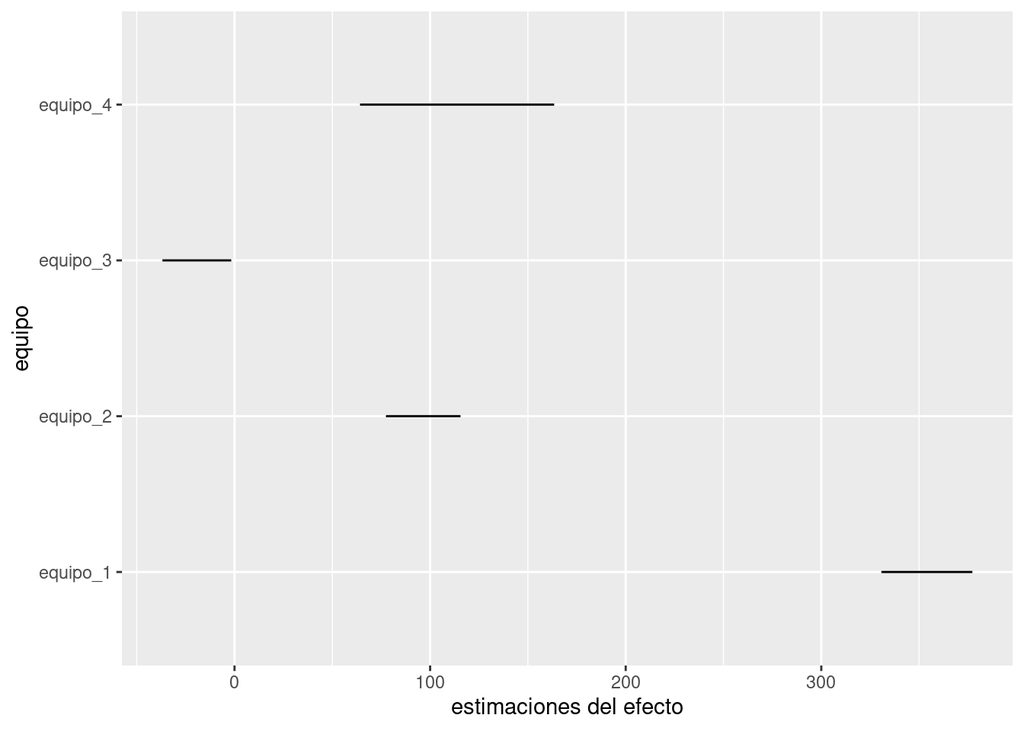

```r
ggplot(estimaciones_95, aes(x = equipo, ymin = inf, ymax = sup)) +
  geom_linerange() + ylab('estimaciones del efecto') + coord_flip()
```

**Respuesta** - Equipo 1 : Estimación inflada por no considerar V1 y por lo tanto no poder condicisionar y aislar el efecto de V1.

- Equipo 2: Buena estimación del efecto

**Pregunta 10**: Argumenta por qué el equipo 2 y el 4 obtienen resultados correctos usando modelos diferentes ¿Su proceso generador tiene el mismo DAG?

**Respuestas** Ambas estimaciones son buenas porque en sus estimaciones el efecto de promoción sobre ventas está asilado. El proceso generador de ambos es diferente. De hecho, estiman el efecto en dos experimentos diferntes.

**Pregunta 11** Argumenta si es apropiado que el equipo 4 utilice en su modelo la variable de ventas del periodo 1 o no, e igualmente con la variable status oro. Explica usando el DAG del equipo 4.

**Respuesta** Pueden incluir la variable V1 y no se activarían rutas no causales. De hecho reducen el error en la estimación del efecto.

Definitivamente, no conviene incluir *Status oro* pues, el coeficiente para Promoción incluiría el efecto de v1 ya que Status oro, activa un camino no causal entre V1 y V2.